# PC3

Franco Hurtado Aguilar

2022-12-02

## Pregunta 1 (10 PUNTOS)

Usar base de datos: “COVID - COMPETITIVIDAD.sav”

```r
library(rio)
data <- import("COVID - COMPETITIVIDAD.sav")
```

1. Elabore un subset con la variable dependiente y las siguientes variables independientes (1pto):

```r
subdata <- data[,c('var11', 'var12', 'var13', 'var14', 'var19', 'var21', 'var22', 'var24', 'var32', 'var34', 'var37', 'var39')]
any(is.na(subdata))
```

```
## [1] FALSE
```

2. Aplique el análisis factorial exploratorio al subset creado, determine el número de factores a utilizar y justifique el por qué elige dicha cantidad de factores (3pts)

En primer lugar, realizamos la matriz de correlaciones.

```r
library(polycor)
corMatrix=polycor::hetcor(subdata)$correlations
corMatrix
```

```
##            var11       var12       var13       var14       var19        var21
## var11  1.0000000  0.44506493  0.62871554  0.45765127 -0.49193912  0.487785240
## var12  0.4450649  1.00000000 -0.05635960  0.02557265 -0.04631268  0.155373764
## var13  0.6287155 -0.05635960  1.00000000  0.88578751 -0.73427836  0.759083552
## var14  0.4576513  0.02557265  0.88578751  1.00000000 -0.72818989  0.845620018
## var19 -0.4919391 -0.04631268 -0.73427836 -0.72818989  1.00000000 -0.639237427
## var21  0.4877852  0.15537376  0.75908355  0.84562002 -0.63923743  1.000000000
## var22 -0.2713656 -0.40490674  0.03822952  0.17690196 -0.22013636  0.009374299
## var24 -0.1768525  0.03482026 -0.52353436 -0.64829160  0.56558467 -0.728964083
## var32  0.3884766  0.16150328  0.57917754  0.70869223 -0.73247526  0.591009637
## var34  0.3397086  0.09617663  0.62863068  0.75573862 -0.75063637  0.645415116
## var37 -0.3722899  0.09036992 -0.79418561 -0.85676450  0.70570284 -0.777589378
## var39 -0.1082938  0.12761458 -0.36191468 -0.29373993  0.07046387 -0.091533126
##              var22       var24      var32       var34       var37       var39
## var11 -0.271365618 -0.17685248  0.3884766  0.33970861 -0.37228994 -0.10829380
## var12 -0.404906738  0.03482026  0.1615033  0.09617663  0.09036992  0.12761458
## var13  0.038229520 -0.52353436  0.5791775  0.62863068 -0.79418561 -0.36191468
## var14  0.176901961 -0.64829160  0.7086922  0.75573862 -0.85676450 -0.29373993
## var19 -0.220136356  0.56558467 -0.7324753 -0.75063637  0.70570284  0.07046387
## var21  0.009374299 -0.72896408  0.5910096  0.64541512 -0.77758938 -0.09153313
## var22  1.000000000 -0.03468396  0.3658452  0.30262636 -0.29352380 -0.21348288
## var24 -0.034683962  1.00000000 -0.5931118 -0.66952910  0.69314634 -0.10264352
## var32  0.365845195 -0.59311176  1.0000000  0.86357209 -0.80936237  0.03749580
## var34  0.302626356 -0.66952910  0.8635721  1.00000000 -0.86146379 -0.13086247
## var37 -0.293523799  0.69314634 -0.8093624 -0.86146379  1.00000000  0.16061919
## var39 -0.213482881 -0.10264352  0.0374958 -0.13086247  0.16061919  1.00000000
```

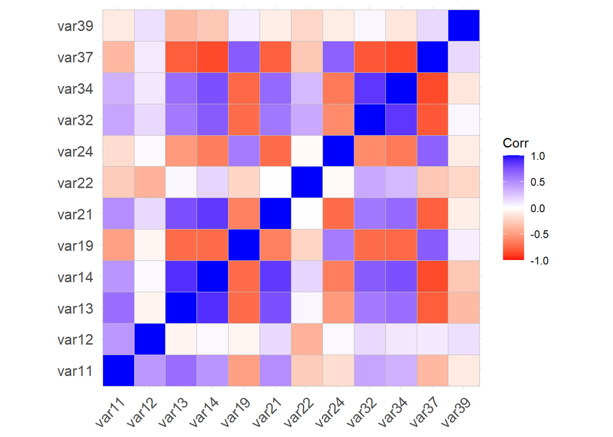

```r
library(ggcorrplot)
ggcorrplot(corMatrix,colors = c("#ff0000", "white", "#0000ff"))
```

Graficamos para poder observar con facilidad el nivel de correlación entre las variables. Algunas de las variables no tienen correlación entre ellas, mientras que existen varios casos tanto de correlación negativa como de positiva, que es lo que nos interesa para crear los factores.

En segundo lugar, aplicamos los tests apropiados para ver si las variables pueden ser factorizadas.

```r
library(psych)
KMO(corMatrix)
```

```
## Kaiser-Meyer-Olkin factor adequacy
## Call: KMO(r = corMatrix)
## Overall MSA =  0.75
## MSA for each item =
## var11 var12 var13 var14 var19 var21 var22 var24 var32 var34 var37 var39
##  0.69  0.28  0.71  0.84  0.83  0.80  0.39  0.83  0.80  0.82  0.82  0.30
```

La prueba de KMO utiliza la matriz de correlaciones para confirmar si las variables pueden ser factorizadas, y debido a que el MSA obtenido es de 0.75, nuestra matriz pasa el test.

```r
cortest.bartlett(corMatrix,n=nrow(subdata))$p.value>0.05
```

```
## [1] FALSE
```

El test de Bartlett nos permite descartar que la matriz creada sea de identidad, lo que desmentimos al obtener un p-value inferior a 0.05.

En tercer lugar, se determina la cantidad de factores que se utilizarán.

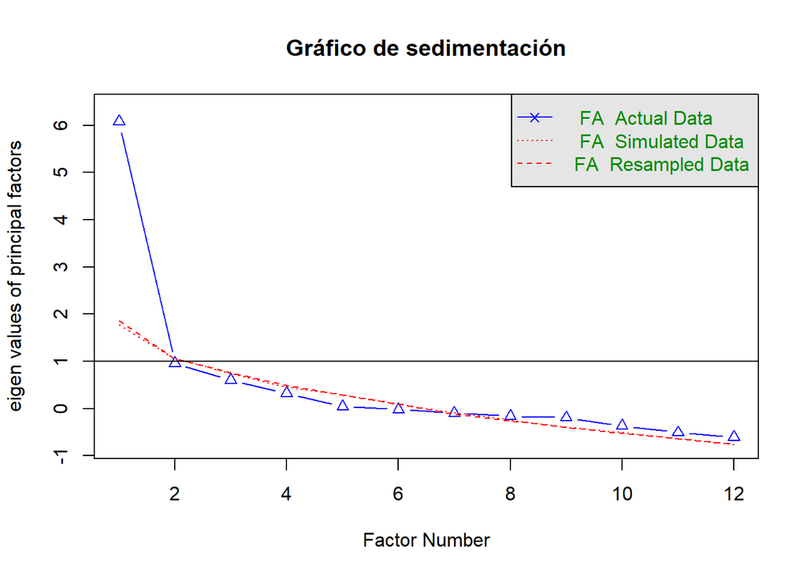

```
## Parallel analysis suggests that the number of factors =  1  and the number of components =  NA
```

```r
fa.parallel(subdata, fm="pa", fa="fa", main = "Gráfico de sedimentación")
```

```r
eigen<-eigen(cor(subdata, use="complete"))
eigen$values
```

```
##  [1] 6.37369839 1.82263207 1.26186087 0.88648244 0.56470066 0.32209667
##  [7] 0.27259500 0.20934208 0.12160333 0.07227447 0.06076551 0.03194851
```

Después de realizar las dos pruebas, se escogerá la cantidad de 3 factores, determinada por la prueba de eigen values debido a su mayor presición, además, considerando la cantidad de variables no sería un análisis productivo trabajar con un solo factor como lo sugiere el gráfico de sedimentación.

3. Identifique y nombre los factores creados a partir de las variables que lo componen. Se recomienda para este ejercicio revisar el diccionario de variables (1pto)

```r
library(GPArotation)
factorial <- fa(subdata,nfactors = 3,rotate = "varimax",fm="minres")
print(factorial$loadings)
```

```
##
## Loadings:
##       MR1    MR2    MR3
## var11  0.395  0.644  0.297
## var12         0.650 -0.226
## var13  0.689  0.184  0.712
## var14  0.829         0.458
## var19 -0.792        -0.194
## var21  0.774  0.240  0.265
## var22  0.253 -0.658
## var24 -0.737
## var32  0.914
## var34  0.914
## var37 -0.909  0.110 -0.261
## var39         0.139 -0.532
##
##                  MR1   MR2   MR3
## SS loadings    5.654 1.408 1.326
## Proportion Var 0.471 0.117 0.111
## Cumulative Var 0.471 0.588 0.699
```

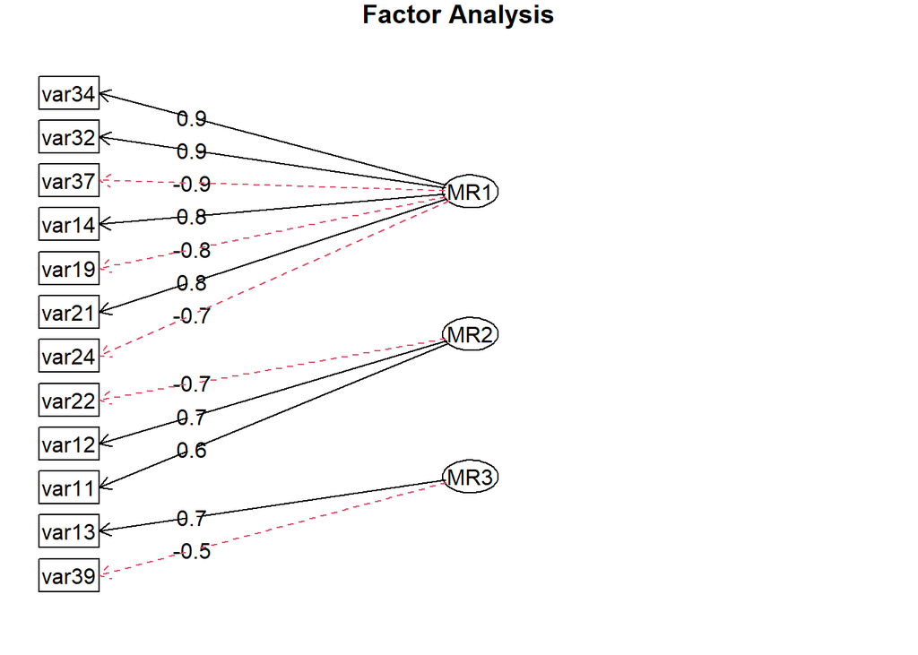

```r
fa.diagram(factorial)
```

Se observan las cargas factoriales de cada variables respecto a su factor, teniendo algunas variables que explican negativamente el comportamiento del factor, pero la mayoría de estas tienen un nivel de explicación alto.

Revisando las variables, podemos determinar a qué se refiere cada uno de los factores. El primero, al tener variables relacionadas al empleo, salud, nutrición, podemos nombrarla como “condiciones de vida”, al describir la manera en la que los encuestados viven. El segundo factor agrupa variables relacionadas al acceso al agua y cobertura hospitalaria, por lo que se puede determinar como “alcance sanitario”, al describir dos tipos de servicios que son resposabilidad del gobierno, como el acceso del agua y de establecimientos de salud. El tercer factor, que abarca las variables de cobertura de desague y ejecución de la inversión pública, se puede determinar como “capacidad para realizar obras”, ya que describe la manera en la que el Estado lleva a cabo proyectos para el beneficio de la comunidad, que se representa en este caso por la cobertura del desague y la ejecución de la inversión a nivel general, pero podría incluir otras variables más específicas.

4. Integre los factores creados a la base de datos y estandarice. Justifique los valores de estandarización (ejemplo: si va de 0 a 100, ¿por qué elije ese rango y no otro rango estandarizado?) (2pts).

```r
factorial_casos<-as.data.frame(factorial$scores)
head(factorial_casos)
```

```
##          MR1         MR2        MR3
## 1 -0.7073339 -0.44384125 -0.2138994
## 2 -0.1206603  0.10381923  0.3025903
## 3 -1.0398395  1.08604187 -0.5794398
## 4  2.0573257  0.94264376 -1.0680384
## 5 -1.1525209  0.88566054  0.9422911
## 6 -1.2138839  0.07440134 -0.3660359
```

```r
summary(factorial_casos)
```

```
##       MR1               MR2                MR3
##  Min.   :-1.5451   Min.   :-2.55539   Min.   :-2.4114
##  1st Qu.:-0.6692   1st Qu.:-0.43671   1st Qu.:-0.6022
##  Median :-0.1462   Median :-0.01903   Median : 0.1729
##  Mean   : 0.0000   Mean   : 0.00000   Mean   : 0.0000
##  3rd Qu.: 0.5120   3rd Qu.: 0.75651   3rd Qu.: 0.8013
##  Max.   : 2.0573   Max.   : 1.25422   Max.   : 1.9044
```

```r
subdata$factor1<- factorial_casos$MR1
subdata$factor2<- factorial_casos$MR2
subdata$factor3<- factorial_casos$MR3
```

```r
library(BBmisc)
subdata$factor1_normalizado = normalize(subdata$factor1,
                                        method = "range",
                                        margin=2, # by column
                                        range = c(0, 100))
subdata$factor2_normalizado = normalize(subdata$factor2,
                                        method = "range",
                                        margin=2, # by column
                                        range = c(0, 100))
subdata$factor3_normalizado = normalize(subdata$factor3,
                                        method = "range",
                                        margin=2, # by column
                                        range = c(0, 100))
summary(subdata$factor1_normalizado)
```

```
##    Min. 1st Qu.  Median    Mean 3rd Qu.    Max.
##    0.00   24.31   38.83   42.89   57.10  100.00
```

```r
summary(subdata$factor2_normalizado)
```

```
##    Min. 1st Qu.  Median    Mean 3rd Qu.    Max.
##    0.00   55.61   66.58   67.08   86.94  100.00
```

```r
summary(subdata$factor3_normalizado)
```

```
##    Min. 1st Qu.  Median    Mean 3rd Qu.    Max.
##    0.00   41.92   59.88   55.87   74.44  100.00
```

Se estandarizarán los factores luego de unirlos a la base de datos. Se escogió una escala de 0 a 100, en primer lugar, porque varios de los datos empezaban en valores negativos, por lo que se debe empezar desde el 0; asimismo, los valores tienen de los factores se distribuyen a varios decimales, por lo que la escala será hasta el 100, si fuera 10 explicaría muy poco la variedad de valores de los casos y si fuera 1000 o más sería muy confuso para entender, teniendo en cuenta además. que varias de las otras variables también están en una escala hasta el 100.

5. Realice un análisis factorial confirmatorio con el modelo identificado y comente, ¿es el conjunto de factores/componentes el adecuado para el trabajo del investigador? A partir de lo obtenido en el modelo confirmatorio, ¿qué conclusiones puede obtener de su análisis? (4pts).

Debido a que ya realizamos la matriz y sus análisis para determinar si es posible factorizar, no será necesario hacer el diagnóstico previo.

```r
library(lavaan)
```

```r
library(semPlot)
```

Determinamos el modelo que hemos creado

```r
Modelo_confir = "FAC1 =~ var14 + var19 + var21 + var24 + var32 + var34 + var37
                FAC2 =~ var11 + var12 + var22
                FAC3 =~ var13 + var39"
Modelo_confir
```

```
## [1] "FAC1 =~ var14 + var19 + var21 + var24 + var32 + var34 + var37    \n                FAC2 =~ var11 + var12 + var22  \n                FAC3 =~ var13 + var39"
```

```r
modelo=cfa(Modelo_confir, data=subdata)
summary(modelo,fit.measures=TRUE)
```

```
## lavaan 0.6-12 did NOT end normally after 512 iterations
## ** WARNING ** Estimates below are most likely unreliable
##
##   Estimator                                         ML
##   Optimization method                           NLMINB
##   Number of model parameters                        27
##
##   Number of observations                            23
##
##
## Parameter Estimates:
##
##   Standard errors                             Standard
##   Information                                 Expected
##   Information saturated (h1) model          Structured
##
## Latent Variables:
##                    Estimate      Std.Err  z-value  P(>|z|)
##   FAC1 =~
##     var14                 1.000
##     var19                -0.535       NA
##     var21                 0.820       NA
##     var24                -0.739       NA
##     var32                23.476       NA
##     var34                 1.245       NA
##     var37                -0.773       NA
##   FAC2 =~
##     var11                 1.000
##     var12                 0.000       NA
##     var22                 0.000       NA
##   FAC3 =~
##     var13                 1.000
##     var39                -0.000       NA
##
## Covariances:
##                    Estimate      Std.Err  z-value  P(>|z|)
##   FAC1 ~~
##     FAC2                 37.942       NA
##     FAC3                120.589       NA
##   FAC2 ~~
##     FAC3                 99.633       NA
##
## Variances:
##                    Estimate      Std.Err  z-value  P(>|z|)
##    .var14                12.459       NA
##    .var19                13.450       NA
##    .var21                21.560       NA
##    .var24                38.328       NA
##    .var32             23074.909       NA
##    .var34                45.481       NA
##    .var37                 6.969       NA
##    .var11          -2795249.268       NA
##    .var12                35.848       NA
##    .var22                 1.076       NA
##    .var13           -881981.667       NA
##    .var39                60.132       NA
##     FAC1                 82.554       NA
##     FAC2            2795357.993       NA
##     FAC3             882224.212       NA
```

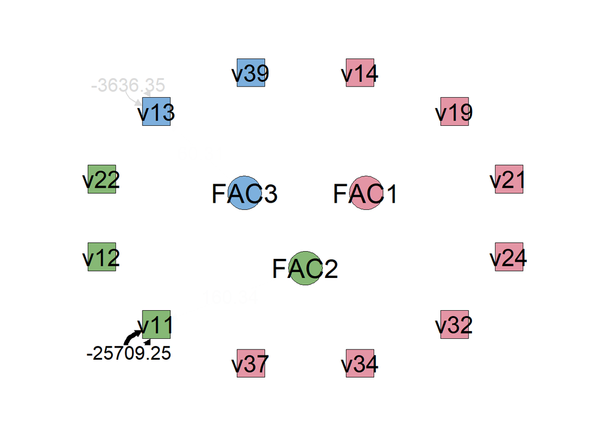

```r
semPaths(modelo, intercepts = FALSE,edge.label.cex=1.5, optimizeLatRes = TRUE, groups = "lat",pastel = TRUE, exoVar = FALSE, sizeInt=5,edge.color ="black",esize = 6, label.prop=2,sizeLat = 6,"std", layout="circle2")
```

Según los resultados obtenidos, no se puede determinar que este modelo sea apropiado para el investigador, el proceso lavaan no puede crear satisfactoriamente el modelo ya que no es adecuado, considerando que tiene un factor muy grande, que abarca la mayoría de variables, mientras otros dos muy pequeños, con 2 y 3 variables respectivamente, lo que resulta en problemas para el proceso lavaan para identificar la significancia de los factores.

## Pregunta 2 (10 PUNTOS)

Utilizando el subset creado en la pregunta anterior, usted ha de elaborar clusters o conglomerados que indiquen qué regiones tienen mayor y menor tendencia a sufrir casos de COVID 19 en el Perú.

```r
library(cluster)
library(factoextra)
library(NbClust)
```

1. Construya un nuevo subset que incluya únicamente las variables “casos_100k” y los factores creados en la pregunta anterior (1pto).

```r
COVID19 <- data.frame(data$casos_100k)
COVID19$factor1 <-subdata$factor1_normalizado
COVID19$factor2 <- subdata$factor2_normalizado
COVID19$factor3 <- subdata$factor3_normalizado
str(COVID19)
```

```
## 'data.frame':    23 obs. of  4 variables:
##  $ data.casos_100k: num  2627 1598 603 2202 1202 ...
##   ..- attr(*, "label")= chr "Casos por cada 100k personas"
##   ..- attr(*, "format.spss")= chr "F8.0"
##   ..- attr(*, "display_width")= int 10
##  $ factor1        : num  23.3 39.5 14 100 10.9 ...
##  $ factor2        : num  55.4 69.8 95.6 91.8 90.3 ...
##  $ factor3        : num  50.9 62.9 42.4 31.1 77.7 ...
```

2. Calcule y construya una matriz de distancias utilizando el método Euclidiano (1pto).

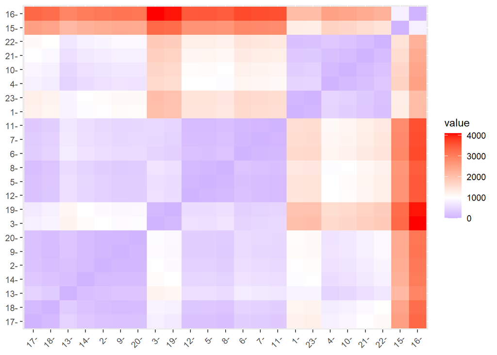

```r
#Calculamos la matriz de distancias usando el método euclidiano
m.distancia <- get_dist(COVID19, method = "euclidean")
#Graficamos
fviz_dist(m.distancia, gradient = list(low = "blue", mid = "white", high = "red"))
```

3. Elabore un análisis de cluster jerárquico y construya el dendrograma respectivo (2pts).

Primero, calculamos el cluster

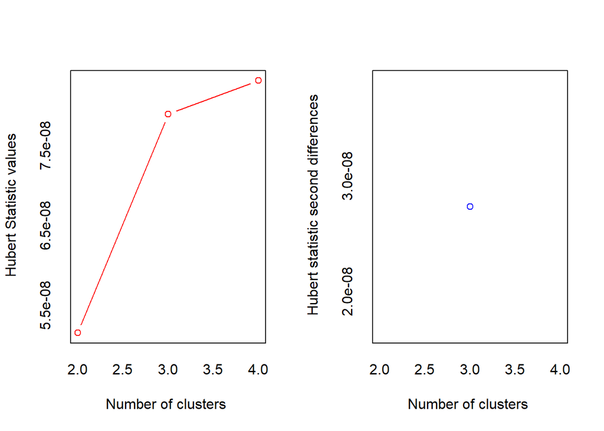

```
## *** : The Hubert index is a graphical method of determining the number of clusters.
##                 In the plot of Hubert index, we seek a significant knee that corresponds to a
##                 significant increase of the value of the measure i.e the significant peak in Hubert
##                 index second differences plot.
##
```

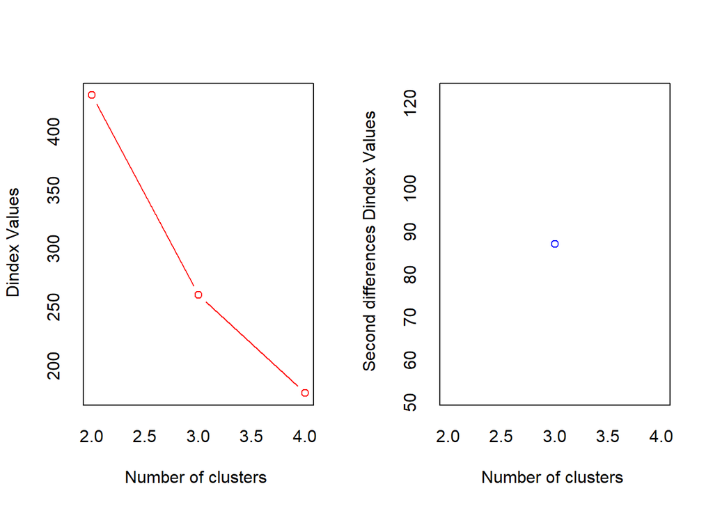

```
## *** : The D index is a graphical method of determining the number of clusters.
##                 In the plot of D index, we seek a significant knee (the significant peak in Dindex
##                 second differences plot) that corresponds to a significant increase of the value of
##                 the measure.
##
## * Among all indices:
## * 1 proposed 2 as the best number of clusters
## * 18 proposed 3 as the best number of clusters
## * 3 proposed 4 as the best number of clusters
##
##                    ***** Conclusion *****
##
## * According to the majority rule, the best number of clusters is  3
##
##
```

```r
library(NbClust)
resnumclust <- NbClust(COVID19, distance = "euclidean", min.nc= 2, max.nc= 4,
                       method = "ward.D")
```

```
## Among all indices:
## ===================
## * 2 proposed  0 as the best number of clusters
## * 1 proposed  1 as the best number of clusters
## * 1 proposed  2 as the best number of clusters
## * 18 proposed  3 as the best number of clusters
## * 3 proposed  4 as the best number of clusters
## * 1 proposed  NA's as the best number of clusters
##
## Conclusion
## =========================
## * According to the majority rule, the best number of clusters is  3 .
```

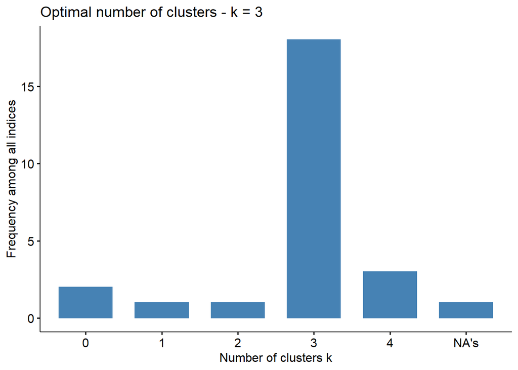

```r
#Se determina un número pequeño de posibilidades de números de cluster ya que la subdata que estamos utilizando tiene un número reducido de casos y variables.
fviz_nbclust(resnumclust)
```

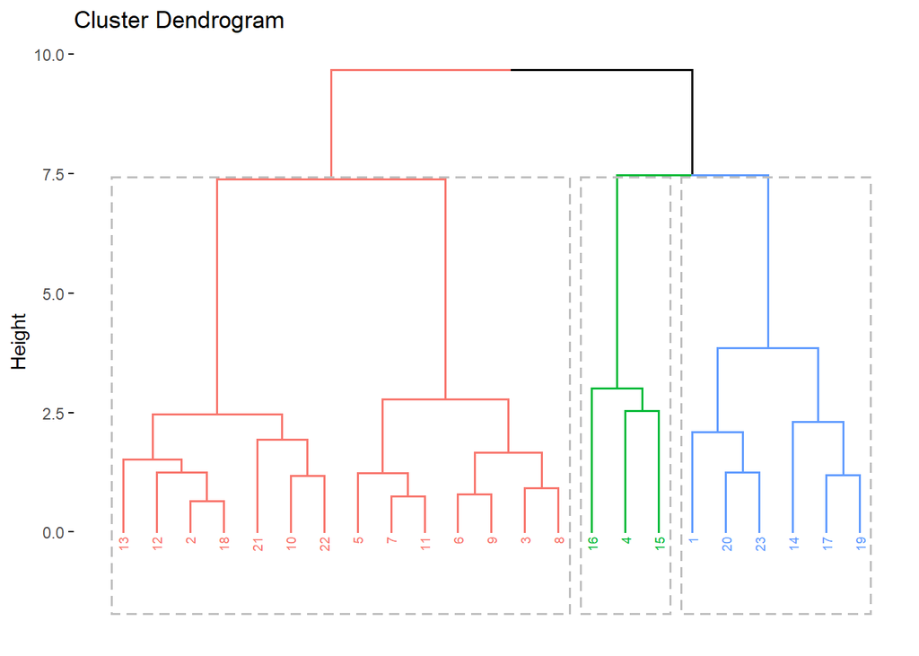

```r
res1 <- hcut(COVID19, k = 3, stand = TRUE, hc_method = "ward.D")
#Determinamos a 3 el número de cortes deseados ya que ese el número óptimo de clusters que nos dio el comando anterior.
fviz_dend(res1, rect = T, cex = 0.5)
```

4. Grafique los clusters determinados con este método (1pto).

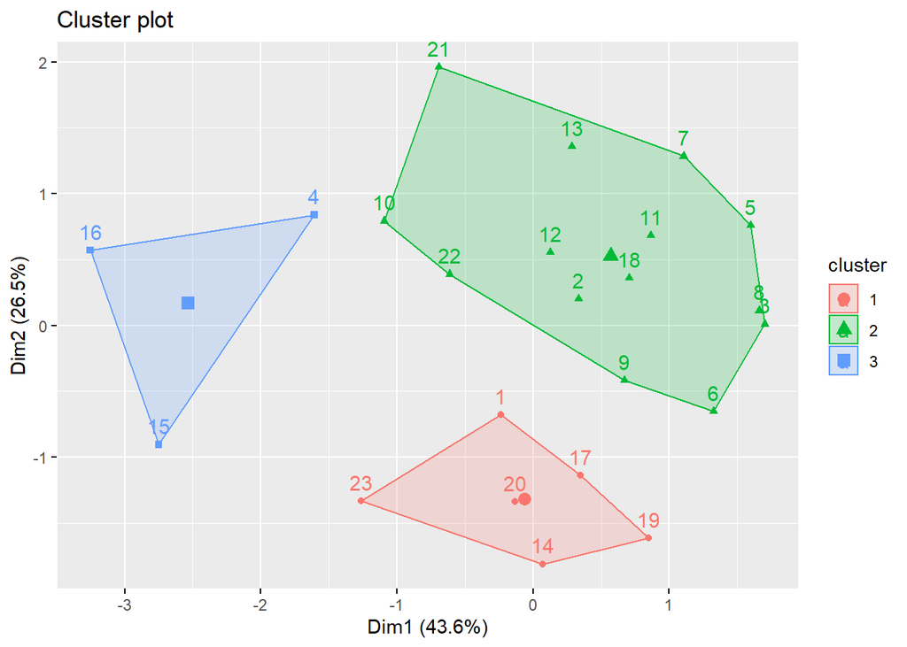

```r
fviz_cluster(res1, data = COVID19)
```

5. Estime el número de clusters con el método de “kmeans”, siendo este número no menor de dos y no mayor que cuatro (1pto)

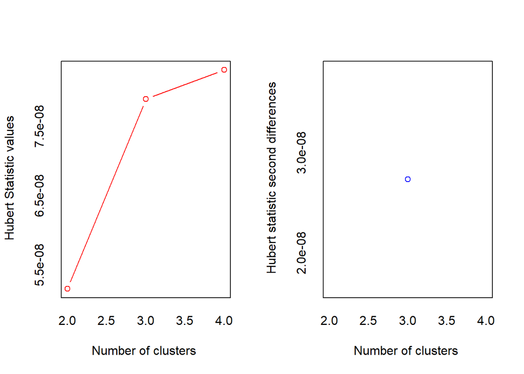

```
## *** : The Hubert index is a graphical method of determining the number of clusters.
##                 In the plot of Hubert index, we seek a significant knee that corresponds to a
##                 significant increase of the value of the measure i.e the significant peak in Hubert
##                 index second differences plot.
##
```

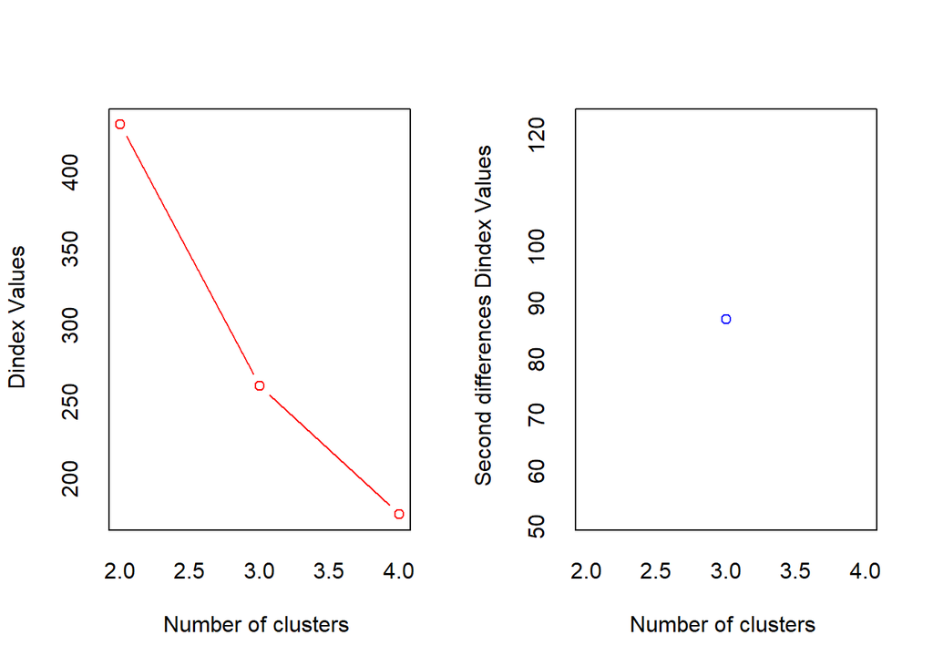

```
## *** : The D index is a graphical method of determining the number of clusters.
##                 In the plot of D index, we seek a significant knee (the significant peak in Dindex
##                 second differences plot) that corresponds to a significant increase of the value of
##                 the measure.
##
## * Among all indices:
## * 1 proposed 2 as the best number of clusters
## * 18 proposed 3 as the best number of clusters
## * 3 proposed 4 as the best number of clusters
##
##                    ***** Conclusion *****
##
## * According to the majority rule, the best number of clusters is  3
##
##
```

```r
resnumclust2 <- NbClust(COVID19, distance = "euclidean", min.nc= 2, max.nc= 4,
                       method = "kmeans")
```

El análisis estima que el número de clústers según el método kmeans es de 3.

6. Determine los clusters a partir del análisis anterior utilizando el método de “kmeans” de y 25 iteraciones (1pto).

```r
clusterskmeans <- kmeans(COVID19, centers = 3, nstart = 25)
clusterskmeans
```

```
## K-means clustering with 3 clusters of sizes 6, 15, 2
##
## Cluster means:
##   data.casos_100k  factor1  factor2  factor3
## 1        2429.000 64.09836 67.19789 56.40140
## 2        1276.533 28.97168 67.81854 59.11913
## 3        4317.000 83.65764 61.15769 29.93989
##
## Clustering vector:
##  [1] 1 2 2 1 2 2 2 2 2 1 2 2 2 2 3 3 2 2 2 2 1 1 1
##
## Within cluster sum of squares by cluster:
## [1]  184052.7 1725010.7  314005.5
##  (between_SS / total_SS =  89.6 %)
##
## Available components:
##
## [1] "cluster"      "centers"      "totss"        "withinss"     "tot.withinss"
## [6] "betweenss"    "size"         "iter"         "ifault"
```

```r
str(clusterskmeans)
```

```
## List of 9
##  $ cluster     : int [1:23] 1 2 2 1 2 2 2 2 2 1 ...
##  $ centers     : num [1:3, 1:4] 2429 1276.5 4317 64.1 29 ...
##   ..- attr(*, "dimnames")=List of 2
##   .. ..$ : chr [1:3] "1" "2" "3"
##   .. ..$ : chr [1:4] "data.casos_100k" "factor1" "factor2" "factor3"
##  $ totss       : num 21348529
##  $ withinss    : num [1:3] 184053 1725011 314006
##  $ tot.withinss: num 2223069
##  $ betweenss   : num 19125460
##  $ size        : int [1:3] 6 15 2
##  $ iter        : int 3
##  $ ifault      : int 0
##  - attr(*, "class")= chr "kmeans"
```

7. Grafique los clusters determinados (1pto).

```
## Too few points to calculate an ellipse
```

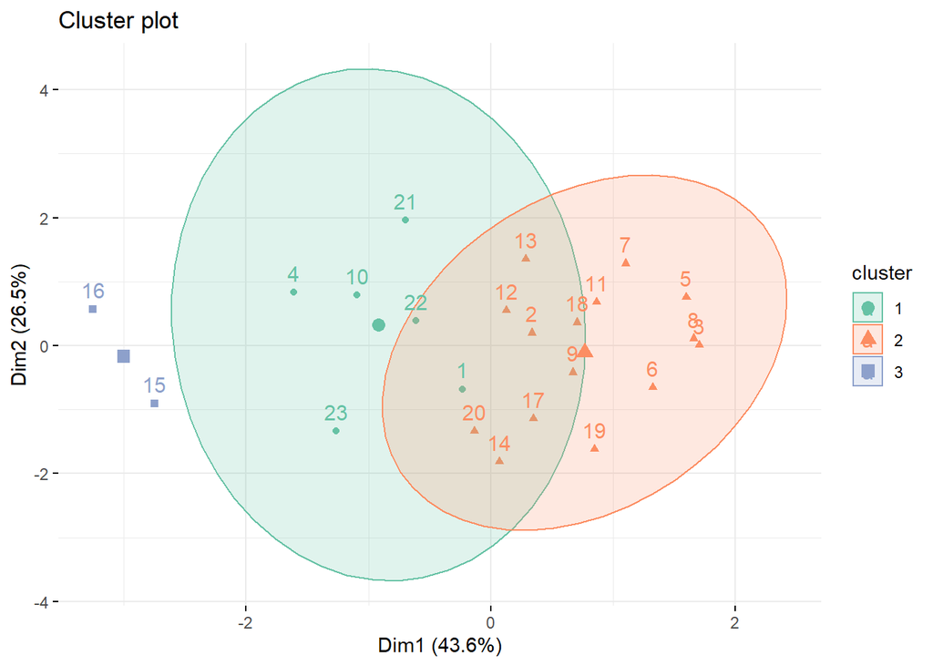

```r
fviz_cluster(clusterskmeans, data = COVID19, ellipse.type = "norm",palette = "Set2", ggtheme = theme_minimal())
```

8. Integre los clusters al último subset creado y colóquelos como “as.numeric” (1pto).

```r
COVID19$clus1 <- as.numeric(res1$cluster)
COVID19$clus2 <- as.numeric(clusterskmeans$cluster)
```

1. Elabore una tabla donde se observen los clusters creados y los valores de los promedios que tienen las variables “casos_100k” y los factores creados en la pregunta 1 (2pts).

```r
library(dplyr)
clust_car1=COVID19 %>%
  mutate(Cluster1 = res1$cluster) %>%
  group_by(Cluster1) %>%
  summarise_all("mean")
clust_car1
```

```
## # A tibble: 3 x 7
##   Cluster1 data.casos_100k factor1 factor2 factor3 clus1 clus2
##      <int>           <dbl>   <dbl>   <dbl>   <dbl> <dbl> <dbl>
## 1        1           1759.    32.5    40.9    38.9     1  1.67
## 2        2           1498.    37.4    77.4    68.6     2  1.79
## 3        3           3612     89.1    71.4    30.3     3  2.33
```

```r
clust_car2=COVID19 %>%
  mutate(Cluster2 = clusterskmeans$cluster) %>%
  group_by(Cluster2) %>%
  summarise_all("mean")
clust_car2
```

```
## # A tibble: 3 x 7
##   Cluster2 data.casos_100k factor1 factor2 factor3 clus1 clus2
##      <int>           <dbl>   <dbl>   <dbl>   <dbl> <dbl> <dbl>
## 1        1           2429     64.1    67.2    56.4  1.83     1
## 2        2           1277.    29.0    67.8    59.1  1.73     2
## 3        3           4317     83.7    61.2    29.9  3        3
```